# Sprawozdanie z zajęć 2 - ilościowe miary ryzyka rynkowego

# Zadanie 1

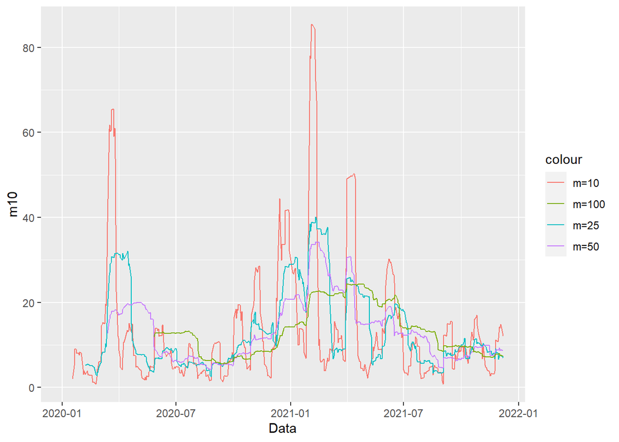

W zależności od doboru m, wykres zmienności zmienia się. Im mniejsze wartości m są wybierane, tym zmienność jest mniej stabilna i mniej odporna na wahania krótkoterminowe. Można zauważyć, że wraz ze wzrostem wartości m, skoki zmienności są coraz mniejsze i coraz bardziej stabilne.

# Zadanie 2

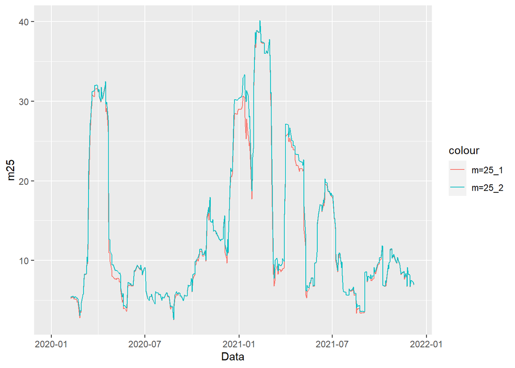

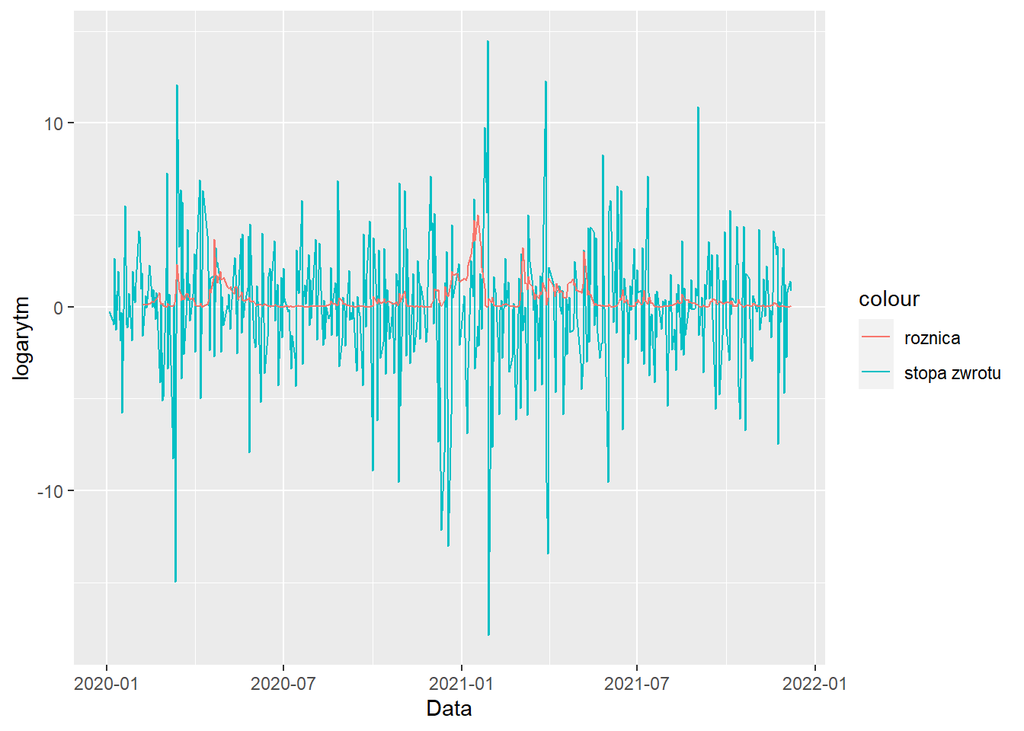

Na podstawie powyższych wykresów mozna postawić tezę, że największe różnice pomiędzy zmiennością stóp zwrotu liczoną na dwa sposoby pojawiają się wtedy, kiedy średnia stopa zwrotu z danego okresu odbiega od zera. Tzn kiey na przykład kilka razy pod rząd wystąpi przewaga wartości dodatnich nad wartościami ujemnymi bądź odwrotnie.

Aby potwierdzić hipotezę, poniżej wykres średnich stóp zwrotu dla m=25:

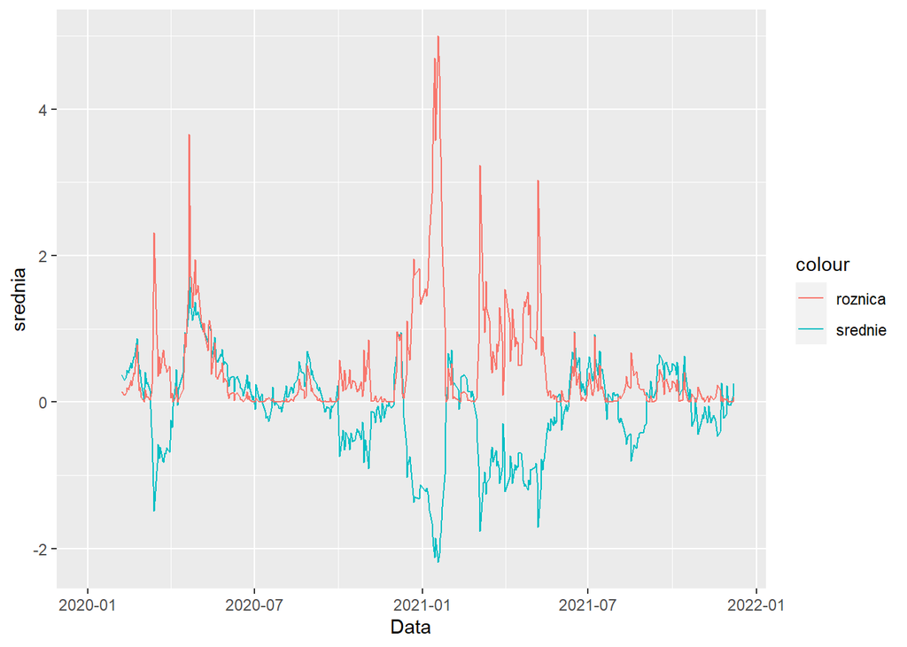

Powyższy wykres potwierdza postawioną wcześniej hipotezę.

# Zadanie 3

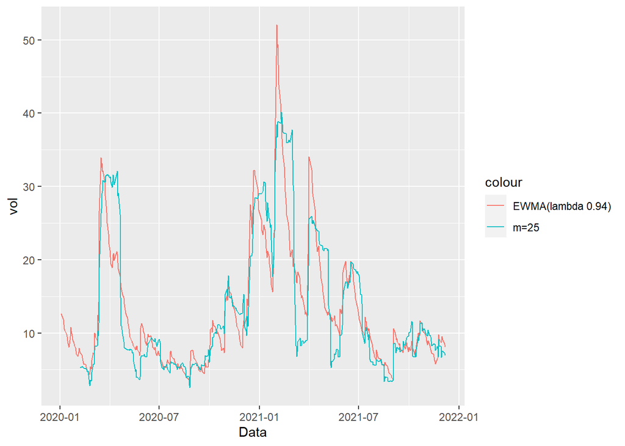

Model EWMA z lambda = 0.94 nie odbiega znacząco od zmienności liczonej przy uzyciu poprzedniego wzoru z m=25

```r
dane2<-ts(na.omit(dane[c(8)])) ## c(8) to stopy zwrotu
Garch<-tseries::garch(dane2)
```

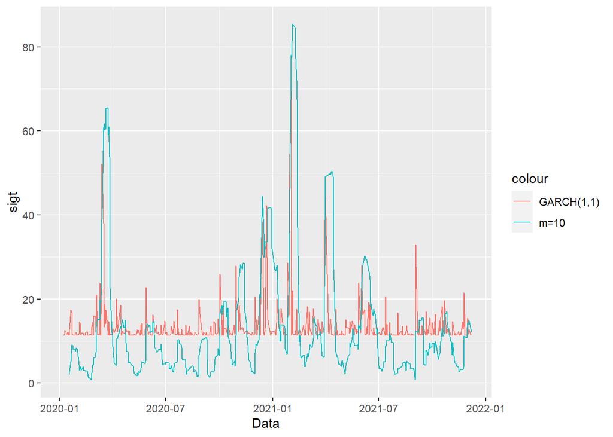

```r
dane$m10<-NA
for(i in 11:length(dane$Data)){
  srednia<-mean(na.omit(dane$logarytm[c((i-10):(i-1))]))
  wartosci<-na.omit(dane$logarytm[c((i-10):(i-1))])
  roznice<- (wartosci-rep(srednia,length(wartosci)))^2
  suma<-1/9*sum(roznice)
  dane$m10[i]<-suma
}
g<-as.data.frame(Garch$fitted.values^2)
g$Data<-dane$Data[2:487]
g$m10<-dane$m10[2:487]
ggplot(g, aes(x=Data)) + geom_line(aes(y=sigt, colour="GARCH(1,1)"))+
  geom_line(aes(y=m10, colour="m=10"))
```

W przypadku modelu GARCH(1,1) wahania wydają się pokrywać z wcześniejszym modelem z m=10.

Tu nie wiem czy jest to dobrze więc udostępniam kod, bo GARCH nie chce zejść poniżej 10.

# Zadanie 4

```
##           AMREST       CCC     MBANK
## AMREST 1.0000000 0.3753292 0.2217991
## CCC    0.3753292 1.0000000 0.3336933
## MBANK  0.2217991 0.3336933 1.0000000
```

# Zadanie 5

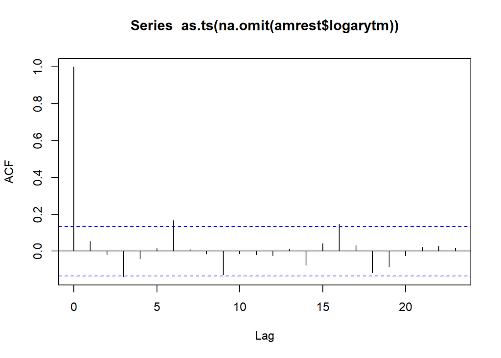

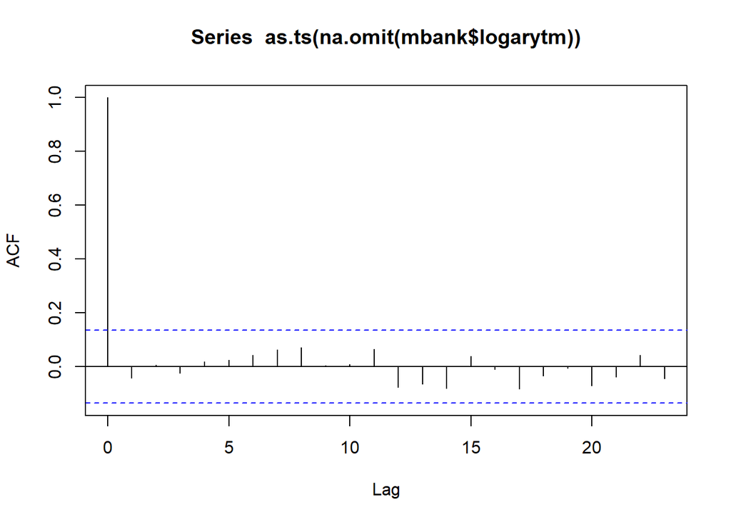

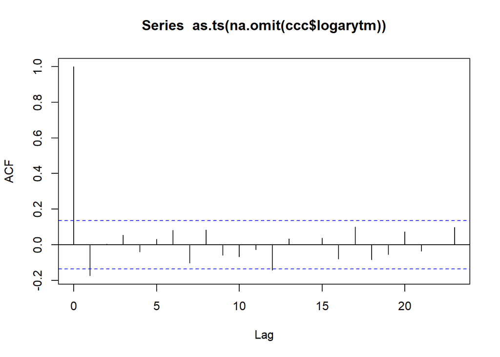

Autokorelacje między stopami zwrotu zmniejszają ryzyko inwestycji, gdyż przy występującej autokorelacji, na podstawie wyników z poprzedniego dnia z przybliżeniem dałoby sie przewidziec wyniki na dzień następny.

# Zadanie 6

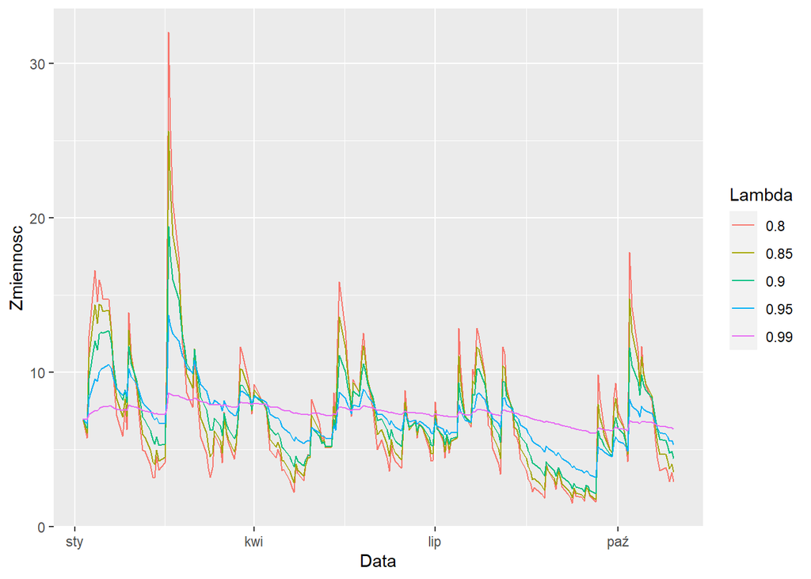

Podobnie jak w przypadku zwiększania wartości m w pierwszym zadaniu, zwiększanie wartości lambda powoduje że model dłużej “pamięta” stare wartości. Zatem im większa lambda, tym zmienność jest bardziej stabilna i odporna na wahania stóp zwrotu.

# Zadanie 7

Aby wyznaczyć lambda, najlepiej oddające zmienność kroczącą, proponowanym rozwiązaniem jest stworzenie wielu modeli EWMA, a następnie porównanie wartości zmienności uzyskanych, ze zmiennościami uzyskanymi metodą kroczącą dla m=25.

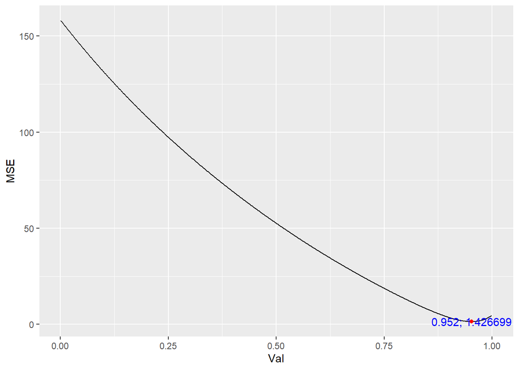

Jak widać na powyższym wykresie, najmniejsza wartość błędu średniokwadratowego jest dla lambdy równej 0.952. Poniżej mozna zobaczyć porównanie obu zmienności na wykresie.

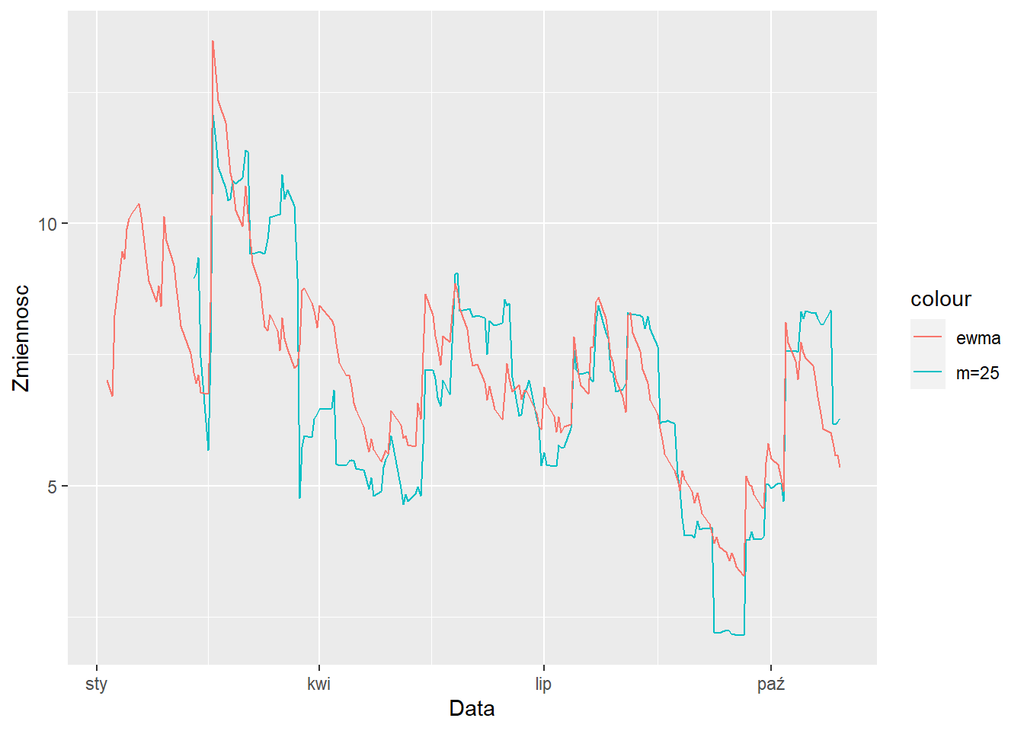